# DSC 478 Assignment3 - Shuyang Ding

# 1. Linear Regression

a. Load and preprocess the data using Pandas or Numpy and, if necessary, preprocessing functions from scikit-learn. The provided data is already normalized (see description), so there is no need for additional normalization. Compute and display basic statistics (mean, standard deviation, min, max, etc.) for each of the variables in the data set. Separate the target attribute for regression. Create a 20%-80% randomized split of the data. Set aside the 20% test portion; the 80% training data partition will be used for cross-validation on various tasks specified below.

```python
import pandas as pd
import numpy as np
import matplotlib.pyplot as plt
from sklearn.model_selection import KFold
from sklearn.linear_model import LinearRegression, Lasso, Ridge, ElasticNet, SGDRegressor
%matplotlib inline
```

```python
community_df = pd.read_csv('C:/Users/shuya/OneDrive/Documents/Depaul/DSC478/Assignment 3/communities/communities.csv',na_values=['?'])
```

```python
community_df.head()
```

|  | state | communityname | population | householdsize | racepctblack | racePctWhite | racePctAsian | racePctHisp | agePct12t21 | agePct12t29 | ... | NumStreet | PctForeignBorn | PctBornSameState | PctSameHouse85 | PctSameCity85 | PctSameState85 | LandArea | PopDens | PctUsePubTrans | ViolentCrimesPerPop |
| --- | --- | --- | --- | --- | --- | --- | --- | --- | --- | --- | --- | --- | --- | --- | --- | --- | --- | --- | --- | --- | --- |
| 0 | 8 | Lakewoodcity | 0.19 | 0.33 | 0.02 | 0.90 | 0.12 | 0.17 | 0.34 | 0.47 | ... | 0.0 | 0.12 | 0.42 | 0.50 | 0.51 | 0.64 | 0.12 | 0.26 | 0.20 | 0.20 |
| 1 | 53 | Tukwilacity | 0.00 | 0.16 | 0.12 | 0.74 | 0.45 | 0.07 | 0.26 | 0.59 | ... | 0.0 | 0.21 | 0.50 | 0.34 | 0.60 | 0.52 | 0.02 | 0.12 | 0.45 | 0.67 |
| 2 | 24 | Aberdeentown | 0.00 | 0.42 | 0.49 | 0.56 | 0.17 | 0.04 | 0.39 | 0.47 | ... | 0.0 | 0.14 | 0.49 | 0.54 | 0.67 | 0.56 | 0.01 | 0.21 | 0.02 | 0.43 |
| 3 | 34 | Willingborotownship | 0.04 | 0.77 | 1.00 | 0.08 | 0.12 | 0.10 | 0.51 | 0.50 | ... | 0.0 | 0.19 | 0.30 | 0.73 | 0.64 | 0.65 | 0.02 | 0.39 | 0.28 | 0.12 |
| 4 | 42 | Bethlehemtownship | 0.01 | 0.55 | 0.02 | 0.95 | 0.09 | 0.05 | 0.38 | 0.38 | ... | 0.0 | 0.11 | 0.72 | 0.64 | 0.61 | 0.53 | 0.04 | 0.09 | 0.02 | 0.03 |

5 rows × 100 columns

```python
community_df.info()
```

```
<class 'pandas.core.frame.DataFrame'>
RangeIndex: 1994 entries, 0 to 1993
Data columns (total 100 columns):
state                    1994 non-null int64
communityname            1994 non-null object
population               1994 non-null float64
householdsize            1994 non-null float64
racepctblack             1994 non-null float64
racePctWhite             1994 non-null float64
racePctAsian             1994 non-null float64
racePctHisp              1994 non-null float64
agePct12t21              1994 non-null float64
agePct12t29              1994 non-null float64
agePct16t24              1994 non-null float64
agePct65up               1994 non-null float64
numbUrban                1994 non-null float64
pctUrban                 1994 non-null float64
medIncome                1994 non-null float64
pctWWage                 1994 non-null float64
pctWFarmSelf             1994 non-null float64
pctWInvInc               1994 non-null float64
pctWSocSec               1994 non-null float64
pctWPubAsst              1994 non-null float64
pctWRetire               1994 non-null float64
medFamInc                1994 non-null float64
perCapInc                1994 non-null float64
whitePerCap              1994 non-null float64
blackPerCap              1994 non-null float64
indianPerCap             1994 non-null float64
AsianPerCap              1994 non-null float64
OtherPerCap              1993 non-null float64
HispPerCap               1994 non-null float64
NumUnderPov              1994 non-null float64
PctPopUnderPov           1994 non-null float64
PctLess9thGrade          1994 non-null float64
PctNotHSGrad             1994 non-null float64
PctBSorMore              1994 non-null float64
PctUnemployed            1994 non-null float64
PctEmploy                1994 non-null float64
PctEmplManu              1994 non-null float64
```

[output cut: 50 more lines]

```
MedOwnCostPctInc         1994 non-null float64
MedOwnCostPctIncNoMtg    1994 non-null float64
NumInShelters            1994 non-null float64
NumStreet                1994 non-null float64
PctForeignBorn           1994 non-null float64
PctBornSameState         1994 non-null float64
PctSameHouse85           1994 non-null float64
PctSameCity85            1994 non-null float64
PctSameState85           1994 non-null float64
LandArea                 1994 non-null float64
PopDens                  1994 non-null float64
PctUsePubTrans           1994 non-null float64
ViolentCrimesPerPop      1994 non-null float64
dtypes: float64(98), int64(1), object(1)
memory usage: 1.5+ MB
```

```python
community_df[community_df.OtherPerCap.isnull()].shape
```

```
(1, 100)
```

```python
OtherPerCap_mean = community_df.OtherPerCap.mean()
community_df.OtherPerCap.fillna(OtherPerCap_mean,axis=0,inplace=True)
```

```python
# Exclude "state" and "community name"
community_df.drop('state',axis=1, inplace=True)
community_df.drop('communityname',axis=1, inplace=True)
```

```python
#Basic Statistics
community_df.describe(include='all')
```

|  | population | householdsize | racepctblack | racePctWhite | racePctAsian | racePctHisp | agePct12t21 | agePct12t29 | agePct16t24 | agePct65up | ... | NumStreet | PctForeignBorn | PctBornSameState | PctSameHouse85 | PctSameCity85 | PctSameState85 | LandArea | PopDens | PctUsePubTrans | ViolentCrimesPerPop |
| --- | --- | --- | --- | --- | --- | --- | --- | --- | --- | --- | --- | --- | --- | --- | --- | --- | --- | --- | --- | --- | --- |
| count | 1994.000000 | 1994.000000 | 1994.000000 | 1994.000000 | 1994.000000 | 1994.000000 | 1994.000000 | 1994.000000 | 1994.000000 | 1994.000000 | ... | 1994.000000 | 1994.000000 | 1994.000000 | 1994.000000 | 1994.000000 | 1994.000000 | 1994.000000 | 1994.000000 | 1994.000000 | 1994.000000 |
| mean | 0.057593 | 0.463395 | 0.179629 | 0.753716 | 0.153681 | 0.144022 | 0.424218 | 0.493867 | 0.336264 | 0.423164 | ... | 0.022778 | 0.215552 | 0.608892 | 0.535050 | 0.626424 | 0.651530 | 0.065231 | 0.232854 | 0.161685 | 0.237979 |
| std | 0.126906 | 0.163717 | 0.253442 | 0.244039 | 0.208877 | 0.232492 | 0.155196 | 0.143564 | 0.166505 | 0.179185 | ... | 0.100400 | 0.231134 | 0.204329 | 0.181352 | 0.200521 | 0.198221 | 0.109459 | 0.203092 | 0.229055 | 0.232985 |
| min | 0.000000 | 0.000000 | 0.000000 | 0.000000 | 0.000000 | 0.000000 | 0.000000 | 0.000000 | 0.000000 | 0.000000 | ... | 0.000000 | 0.000000 | 0.000000 | 0.000000 | 0.000000 | 0.000000 | 0.000000 | 0.000000 | 0.000000 | 0.000000 |
| 25% | 0.010000 | 0.350000 | 0.020000 | 0.630000 | 0.040000 | 0.010000 | 0.340000 | 0.410000 | 0.250000 | 0.300000 | ... | 0.000000 | 0.060000 | 0.470000 | 0.420000 | 0.520000 | 0.560000 | 0.020000 | 0.100000 | 0.020000 | 0.070000 |
| 50% | 0.020000 | 0.440000 | 0.060000 | 0.850000 | 0.070000 | 0.040000 | 0.400000 | 0.480000 | 0.290000 | 0.420000 | ... | 0.000000 | 0.130000 | 0.630000 | 0.540000 | 0.670000 | 0.700000 | 0.040000 | 0.170000 | 0.070000 | 0.150000 |
| 75% | 0.050000 | 0.540000 | 0.230000 | 0.940000 | 0.170000 | 0.160000 | 0.470000 | 0.540000 | 0.360000 | 0.530000 | ... | 0.000000 | 0.280000 | 0.777500 | 0.660000 | 0.770000 | 0.790000 | 0.070000 | 0.280000 | 0.190000 | 0.330000 |
| max | 1.000000 | 1.000000 | 1.000000 | 1.000000 | 1.000000 | 1.000000 | 1.000000 | 1.000000 | 1.000000 | 1.000000 | ... | 1.000000 | 1.000000 | 1.000000 | 1.000000 | 1.000000 | 1.000000 | 1.000000 | 1.000000 | 1.000000 | 1.000000 |

8 rows × 98 columns

```python
#Separate attributes
target = pd.DataFrame(community_df["ViolentCrimesPerPop"])
target.head(5)
```

|  | ViolentCrimesPerPop |
| --- | --- |
| 0 | 0.20 |
| 1 | 0.67 |
| 2 | 0.43 |
| 3 | 0.12 |
| 4 | 0.03 |

```python
community_df.drop('ViolentCrimesPerPop',axis=1, inplace=True)
```

```python
# 20%-80% split
from sklearn.model_selection import train_test_split
community_train, community_test, target_train, target_test = train_test_split(community_df, target, test_size=0.2, random_state=79)
```

b.Perform standard linear regression on data using the closed form solution implementation (not the scikit-learn implementation). Compute the RMSE value on the full training data (the 80% partition). Also, plot the correlation between the predicted and actual values of the target attribute. Display the obtained regression coefficients (weights) and plot them using matplotlib. Finally, perform 10-fold cross-validation and compare the cross-validation RMSE to the training RMSE (for cross validation, you should use the KFold module from sklearn.model_selection).

```python
# In order to do multiple regression we need to add a column of 1s as the coefficient for x0
community_array = np.array(community_df)
x = np.array([np.concatenate((v,[1])) for v in community_array])
x
```

```
array([[0.19, 0.33, 0.02, ..., 0.26, 0.2 , 1.  ],
       [0.  , 0.16, 0.12, ..., 0.12, 0.45, 1.  ],
       [0.  , 0.42, 0.49, ..., 0.21, 0.02, 1.  ],
       ...,
       [0.16, 0.37, 0.25, ..., 0.32, 0.18, 1.  ],
       [0.08, 0.51, 0.06, ..., 0.38, 0.33, 1.  ],
       [0.2 , 0.78, 0.14, ..., 0.3 , 0.05, 1.  ]])
```

```python
x.shape
```

```
(1994, 98)
```

```python
y = np.array(target)
y
```

```
array([[0.2 ],
       [0.67],
       [0.43],
       ...,
       [0.23],
       [0.19],
       [0.48]])
```

```python
y.shape
```

```
(1994, 1)
```

```python
def standRegres(xArr,yArr):
    xMat = np.matrix(xArr); yMat = np.matrix(yArr).T
    xTx = xMat.T*xMat
    if np.linalg.det(xTx) == 0.0:
        print("This matrix is singular, cannot do inverse")
        return
    ws = xTx.I * (xMat.T*yMat.T)
    return ws
```

```python
ws = standRegres(x,y)
ws
```

```
matrix([[ 1.31108068e-01],
        [-3.14114977e-02],
        [ 2.09909670e-01],
        [-4.05351612e-02],
        [-1.38892919e-02],
        [ 5.89726825e-02],
        [ 1.23399025e-01],
        [-2.22621600e-01],
        [-1.47500199e-01],
        [ 5.01635477e-02],
        [-2.42413829e-01],
        [ 4.64024392e-02],
        [-1.96945615e-01],
        [-2.06117500e-01],
        [ 4.65935490e-02],
        [-1.77212915e-01],
        [ 6.30148504e-02],
        [ 1.14942190e-02],
        [-9.08951848e-02],
        [ 2.74640044e-01],
        [ 1.01752476e-01],
        [-3.31517562e-01],
        [-2.91799268e-02],
        [-3.54483393e-02],
        [ 2.26173855e-02],
        [ 4.30950137e-02],
        [ 3.44408548e-02],
        [ 1.28412458e-01],
        [-1.91293360e-01],
        [-1.00769002e-01],
        [ 6.46856092e-02],
        [ 1.06062117e-01],
        [ 2.44125991e-06],
        [ 2.34984611e-01],
        [-3.75705330e-02],
        [-7.74957660e-03],
        [ 4.66779619e-01],
        [ 2.26295907e-01],
        [ 1.74621953e-01],
        [-5.75206227e-01],
```

[output cut: 43 more lines]

```
        [ 3.74730887e-01],
        [ 4.17402525e-02],
        [-4.45747318e-02],
        [-8.34683479e-02],
        [ 1.30736305e-01],
        [ 1.83468559e-01],
        [ 1.26046949e-01],
        [ 4.63490658e-03],
        [-2.24577196e-02],
        [ 2.88627319e-02],
        [ 1.30622513e-02],
        [ 2.76170980e-02],
        [-1.24479622e-02],
        [-3.73099899e-02],
        [ 5.88079813e-01]])
```

```python
# compute the predicted values:
xMat=np.mat(x)
yHat = xMat*ws
yHat
```

```
matrix([[0.16551838],
        [0.29062973],
        [0.38367799],
        ...,
        [0.40142767],
        [0.16882645],
        [0.37326947]])
```

```python
# Compute RMSE on training data
# Errors on training data
error = abs(yHat - y)
print(error[:10])
```

```
[[0.03448162]
 [0.37937027]
 [0.04632201]
 [0.20270857]
 [0.05129155]
 [0.09017938]
 [0.05800201]
 [0.1076608 ]
 [0.29252029]
 [0.14473903]]
```

```python
# Dot product of error vector with itself gives us the sum of squared errors
total_error = np.dot(error.T,error)

# Compute RMSE
rmse_train = np.sqrt(total_error/len(yHat))
print("RMSE on Training Data: ", rmse_train)
```

```
RMSE on Training Data:  [[0.12888961]]
```

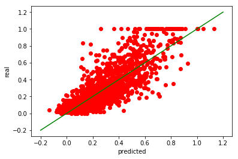

```python
# Plot predicted and actual values
plt.plot(yHat, y,'ro')
plt.plot([-.2,1.2],[-.2,1.2], 'g-')
plt.xlabel('predicted')
plt.ylabel('real')
plt.show()
```

```python
# Create linear regression object
linreg = LinearRegression()
```

```python
def cross_validate(model, X, y, n, verbose=False):
    from sklearn.model_selection import KFold
    kf = KFold(n_splits=n, random_state=22)
    xval_err = 0
    f = 1
    for train,test in kf.split(x):
        model.fit(X[train],y[train])
        p = model.predict(x[test])
        e = p-y[test]
        rmse = np.sqrt(np.dot(e.T,e)/len(x[test]))
        if verbose:
            print("Fold %2d RMSE: %.4f" % (f, rmse))
        xval_err += rmse
        f += 1
    return xval_err/n
```

```python
rmse_10cv = cross_validate(linreg, x, y, 10, verbose=True)
```

```
Fold  1 RMSE: 0.1468
Fold  2 RMSE: 0.1364
Fold  3 RMSE: 0.1620
Fold  4 RMSE: 0.1401
Fold  5 RMSE: 0.1312
Fold  6 RMSE: 0.1239
Fold  7 RMSE: 0.1273
Fold  8 RMSE: 0.1242
Fold  9 RMSE: 0.1303
Fold 10 RMSE: 0.1364
```

```python
# Compare the cross-validation RMSE to the training RMSE
method_name = 'Simple Linear Regression'
print('Method: %s' %method_name)
print('RMSE on training: %.4f' %rmse_train)
print('RMSE on 10-fold CV: %.4f' %rmse_10cv)
```

```
Method: Simple Linear Regression
RMSE on training: 0.1289
RMSE on 10-fold CV: 0.1359
```

c. Feature Selection: use the scikit-learn regression model from sklearn.linear_model with a subset of features to perform linear regression. For feature selection, write a script or function that takes as input the training data, target variable; the model; and any other parameters you find necessary, and returns the optimal percentage of the most informative features to use. Your approach should use k-fold cross-validation on the training data (you can use k=5). You can use feature_selection.SelectPercentile to find the most informative variables. Show the list of most informative variables and their weights

```python
from sklearn import feature_selection
from sklearn.model_selection import cross_val_score
```

```python
xf = np.array(community_df)
xf = np.array([np.concatenate((v, [1])) for v in x])
yf = np.array(target)
```

```python
xf_train, xf_test, yf_train, yf_test = train_test_split(xf, yf, test_size=0.2, random_state=33)
```

```python
print (xf_train.shape)
print (yf_train.shape)
print (xf_test.shape)
print (yf_test.shape)
```

```
(1595, 99)
(1595, 1)
(399, 99)
(399, 1)
```

```python
linreg = LinearRegression()
```

```python
import warnings
warnings.filterwarnings('ignore')
```

```
1 0.5497462154012411
6 0.609462417806909
11 0.6188591701442954
16 0.6234219314963412
21 0.6341268202083284
26 0.6491115775710352
31 0.651829991247554
36 0.6528540418586671
41 0.6532362985512379
46 0.6513878254215715
51 0.6501808688616669
56 0.6522390048676718
61 0.6532579587547073
66 0.6540008668740998
71 0.6528653961316546
76 0.657857706866471
81 0.6565039448165363
86 0.6580084293242422
91 0.658247369830254
96 0.6580657068238263
Optimal percentile of features:91

Optimal number of features:88
```

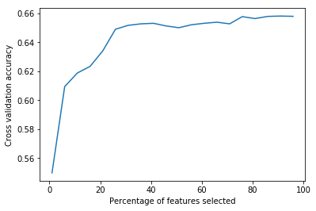

```python
percentiles = range(1, 100, 5)
results = []
for i in range(1, 100, 5):
    fs = feature_selection.SelectPercentile(feature_selection.f_regression, percentile = i)
    x_train_fs = fs.fit_transform(xf_train, yf_train)
    scores = abs(cross_val_score(linreg, x_train_fs, yf_train, cv=5))
    print(i, scores.mean())
    results = np.append(results, scores.mean())

optimal_percentil = np.where(results == results.max())[0][0]
print("Optimal percentile of features:{0}".format(percentiles[optimal_percentil]), "\n")
optimal_num_features = int((percentiles[optimal_percentil] * len(community_df.columns) / 100))
print("Optimal number of features:{0}".format(optimal_num_features), "\n")

import pylab as pl
pl.figure()
pl.xlabel("Percentage of features selected")
pl.ylabel("Cross validation accuracy")
pl.plot(percentiles, results)
```

```python
fs = feature_selection.SelectPercentile(feature_selection.f_regression, percentile = 91)
x_train_fs = fs.fit_transform(xf_train, yf_train)

for i in range(len(community_df.columns.values)):
    if fs.get_support()[i]:
        print(community_df.columns.values[i],'\t\t', fs.scores_[i])
```

```
population 		 256.0323547372119
racepctblack 		 1074.8895092675182
racePctWhite 		 1412.5078123926182
racePctHisp 		 137.54043215677945
agePct12t21 		 4.894803532795885
agePct12t29 		 37.33401496511649
agePct16t24 		 15.875055643949656
agePct65up 		 8.24793840554492
numbUrban 		 247.77613854814769
pctUrban 		 11.060895847737783
medIncome 		 341.63253752319906
pctWWage 		 161.57075094157008
pctWFarmSelf 		 40.344220298786475
pctWInvInc 		 756.0149723312603
pctWSocSec 		 22.486379068174298
pctWPubAsst 		 784.5706408092585
pctWRetire 		 13.975623750024466
medFamInc 		 366.90042184405735
perCapInc 		 214.99315799069268
whitePerCap 		 65.44623454922922
blackPerCap 		 126.57709861890363
indianPerCap 		 12.31709544455491
AsianPerCap 		 29.069227068933138
OtherPerCap 		 33.36930259404467
HispPerCap 		 92.36570683066381
NumUnderPov 		 400.3078568907944
PctPopUnderPov 		 578.817365213762
PctLess9thGrade 		 319.21810810192477
PctNotHSGrad 		 472.19620786905836
PctBSorMore 		 173.3668431842858
PctUnemployed 		 533.9131521991949
PctEmploy 		 190.4652624638389
PctEmplProfServ 		 7.3990749948544945
MalePctDivorce 		 602.7748935815926
MalePctNevMarr 		 161.07842259577544
FemalePctDiv 		 704.7727390048145
TotalPctDiv 		 693.1378303821931
PersPerFam 		 24.46806220870238
PctFam2Par 		 1657.8650169982202
PctKids2Par 		 1972.804063866535
```

[output cut: 35 more lines]

```
RentLowQ 		 104.02885733441974
RentMedian 		 95.72437888918316
RentHighQ 		 90.25437367854325
MedRent 		 95.91995628599564
MedRentPctHousInc 		 178.68419423618977
MedOwnCostPctInc 		 6.724749880887582
NumInShelters 		 265.84594187525437
NumStreet 		 169.53426122290406
PctForeignBorn 		 61.96200805216774
PctBornSameState 		 9.70709440682873
PctSameHouse85 		 40.927451922997385
PctSameCity85 		 9.17263688850588
LandArea 		 61.980585133652575
PopDens 		 142.6901578134151
PctUsePubTrans 		 40.12079381252858
```

```python
from sklearn.metrics import mean_absolute_error

fs = feature_selection.SelectPercentile(feature_selection.f_regression, percentile = 96)
x_train_fs = fs.fit_transform(xf_train, yf_train)
linreg = LinearRegression()
linreg.fit(x_train_fs, yf_train)
x_test_fs = fs.transform(xf_test)
linreg_pred = linreg.predict(x_test_fs)
linreg_meanerr = mean_absolute_error(yf_test, linreg_pred)
print("Mean Absolute error is %.4f" %linreg_meanerr)
```

```
Mean Absolute error is 0.1011
```

```python
yf_test.shape
```

```
(399, 1)
```

```python
# Train on the full 80% adn evaluate using the set-aside 20% test
from sklearn import metrics
linreg_f = LinearRegression()
linreg_f.fit(xf_train, yf_train)
linred_pred_fs = linreg.predict(test_fs)

scores = abs(cross_val_score(linreg_f,linred_pred_fs , yf_test, cv=5))
print(scores.mean())
```

```
0.6095475230507795
```

d.Next, perform Ridge Regression and Lasso Regression using the modules from sklearn.linear_model. In each case, perform systematic model selection to identify the optimal alpha parameter. You should create a function that takes as input the data and target variable; the parameter to vary and a list of its values; the model to be trained; and any other relevant input needed to determine the optimal value for the specified parameter. The model selection process should perform k-fold cross validation (k should be a parameter, but you can select k=5 for this problem). For each model, you should also plot the error values on the training and cross-validation splits across the specified values of the alpha parameter. Finally, using the best alpha values, train the model on the full training data and evaluate it on the set-aside test data. Discuss your observation and conclusions

```python
xr_train, xr_test, yr_train, yr_test = train_test_split(x, y, test_size=0.2, random_state=37)
```

```python
def calc_params(X,Y, param_values, param_name, K, model, model_name):
    X = np.array(X)
    Y = np.array(Y)

    # initialize training and testing score arrays with zeros
    train_scores = np.zeros(len(param_values))
    test_scores = np.zeros(len(param_values))

    # iterate over the different parameter values
    for i, param_value in enumerate(param_values):

        model.set_params(**{param_name:param_value})

        k_train_scores = np.zeros(K)
        k_test_scores = np.zeros(K)

        cv = KFold(n_splits=K, shuffle=True, random_state=0)

        j = 0
        for train, test in cv.split(X):
            # fit the classifier in the corresponding fold
            # and obtain the corresponding accuracy scores on train and test sets
            model.fit(X[train], y[train])
            train_predict = model.predict(X[train])
            test_predict = model.predict(X[test])
            j += 1

            k_train_scores = mean_absolute_error(y[train], train_predict)
            k_test_scores = mean_absolute_error(y[test], test_predict)

        train_scores[i] = np.mean(k_train_scores)
        test_scores[i] = np.mean(k_test_scores)

    plt.plot(param_values, train_scores, label = 'Train', alpha = 0.4, lw = 2, c = 'b')
    plt.plot(param_values, test_scores, label = 'X-Val', alpha = 0.4, lw = 2, c = 'r')
    plt.legend(loc=7)
    plt.xlabel(param_name + " values")
    plt.ylabel("Mean cross validation error")

    min_err = np.where(test_scores == test_scores.min())
    min_err_alpha = param_values[min_err]
    print('The minimum Mean absolute error is:', test_scores[min_err][0],'alpha is', min_err_alpha[0])
```

```python
alpha = np.linspace(.01,100,50)
alpha = np.array([float(e) for e in alpha])
```

```
The minimum Mean absolute error is: 0.17614849401080226 alpha is 67.35020408163265
```

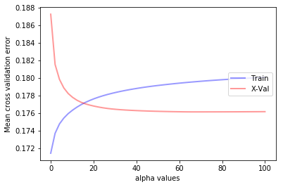

```python
# Ridge Regression
ridge = Ridge()
calc_params(xr_train, yr_train, alpha, "alpha", 5, ridge, "Ridge Regression")
```

```python
ridge = Ridge(fit_intercept = True, alpha = 67.35020408163265)
ridge.fit(xr_test, yr_test)
pred = ridge.predict(xr_test)
err = pred-yr_test
total_error = np.dot(err.T,err)
rmse_train = np.sqrt(total_error/len(pred))


#5-fold cross-validation
kf = KFold(n_splits=5, random_state=22)
xval_err = 0
for train,test in kf.split(xr_train):
    ridge.fit(xr_train[train],yr_train[train])
    p = ridge.predict(xr_train[test])
    e = p-yr_train[test]
    xval_err += np.dot(e.T,e)
    rmse_5cv = np.sqrt(xval_err/len(xr_train))

method_name = 'Ridge Regression'
print('Method: %s' %method_name)
print('RMSE on training: %.4f' %rmse_trainl)
print('RMSE on 5-fold CV: %.4f' %rmse_5cv)
```

[output not shown]

```
The minimum Mean absolute error is: 0.17665827281571525 alpha is 0.01
```

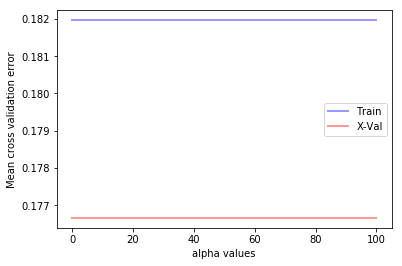

```python
# Lasso Regression
lasso = Lasso()
calc_params(xr_train, yr_train, alpha, "alpha", 5, lasso, "Lasso Regression")
```

```python
lasso = Lasso(fit_intercept = True, alpha = 0.01)
lasso.fit(xr_test, yr_test)
predl = lasso.predict(xr_test)
pred_n = predl.reshape(399,1)
errl = pred_n-yr_test
total_errorl = np.dot(errl.T,errl)
rmse_trainl = np.sqrt(total_errorl/len(pred_n))

#5-fold cross-validation
kf = KFold(n_splits=10, random_state=22)
xval_err = 0
for train,test in kf.split(xr_train):
    lasso.fit(xr_train[train],yr_train[train])
    p = lasso.predict(xr_train[test])
    e = p-yr_train[test]
    xval_err += np.dot(e.T,e)
    rmse_5cv = np.sqrt(xval_err/len(xr_train))

method_name = 'Lasso Regression'
print('Method: %s' %method_name)
print('RMSE on training: %.4f' %rmse_trainl)
print('RMSE on 5-fold CV: %.4f' %rmse_5cv)
```

[output not shown]

e. Next, perform regression using Stochastic Gradient Descent for regression. For this part, you should use the SGDRegessor module from sklearn.linear_model. Note that SGDRegessor requires that features be standardized (with 0 mean and scaled by standard deviation). Prior to fiting the model, perform the scaling using StandardScaler from sklearn.preprocessing. For this problem, perform a grid search (using GridSearchCV from sklearn.grid_search) Your grid search should compare combinations of two penalty parameters ('l2', 'l1') and different values of alpha (alpha could vary from 0.0001 which is the default to relatively large values, say 10). Using the best parameters, apply the model to the set-aside test data. Finally, perform model selection (similar to part d, above) to find the best "l1_ratio" parameter using SGDRegressor with the "elasticnet" penalty parameter

```python
from sklearn.preprocessing import StandardScaler
from sklearn.model_selection import GridSearchCV
```

```python
S = StandardScaler()
S.fit(x)
xnormalized = S.transform(x)
xs_train, xs_test, ys_train, ys_test = train_test_split(xnormalized, y, test_size=0.2, random_state=33)
```

```python
sgd = SGDRegressor()
parameters = {
    'penalty': ['l1', 'l2'],
    'alpha': np.linspace(0.0001, 0.05, 10)}
gs = GridSearchCV(sgd, parameters, verbose=1, cv=5)
```

```python
gs.fit(xnormalized, y)
```

```
Fitting 5 folds for each of 20 candidates, totalling 100 fits
```

```
[Parallel(n_jobs=1)]: Using backend SequentialBackend with 1 concurrent workers.
[Parallel(n_jobs=1)]: Done 100 out of 100 | elapsed:    0.6s finished
```

```
GridSearchCV(cv=5, error_score='raise-deprecating',
       estimator=SGDRegressor(alpha=0.0001, average=False, early_stopping=False, epsilon=0.1,
       eta0=0.01, fit_intercept=True, l1_ratio=0.15,
       learning_rate='invscaling', loss='squared_loss', max_iter=None,
       n_iter=None, n_iter_no_change=5, penalty='l2', power_t=0.25,
       random_state=None, shuffle=True, tol=None, validation_fraction=0.1,
       verbose=0, warm_start=False),
       fit_params=None, iid='warn', n_jobs=None,
       param_grid={'penalty': ['l1', 'l2'], 'alpha': array([0.0001 , 0.00564, 0.01119, 0.01673, 0.02228, 0.02782, 0.03337,
       0.03891, 0.04446, 0.05   ])},
       pre_dispatch='2*n_jobs', refit=True, return_train_score='warn',
       scoring=None, verbose=1)
```

```python
gs.best_params_, gs.best_score_
```

```
({'alpha': 0.03891111111111112, 'penalty': 'l2'}, 0.6479031769054845)
```

```python
for (i, j) in gs.best_params_.items():
    sgd.set_params(**{i:j})
    print ("The optimum value of", i, "is estimated as", j, "\n")
```

```
The optimum value of alpha is estimated as 0.03891111111111112

The optimum value of penalty is estimated as l2
```

```python
sgdr = SGDRegressor(penalty = 'l2', alpha = 0.03891111111111112)
sgdr.fit(xs_train, ys_train)
pred = sgdr.predict(xs_test)
mae = mean_squared_error(ys_test, pred)

print ('Mean Absolute error of set-aside test data set: %0.8f' % mae)
```

```
Mean Absolute error of set-aside test data set: 0.02146567
```

```python
sgdreg = SGDRegressor()
sgdreg.get_params()
```

```
{'alpha': 0.0001,
 'average': False,
 'early_stopping': False,
 'epsilon': 0.1,
 'eta0': 0.01,
 'fit_intercept': True,
 'l1_ratio': 0.15,
 'learning_rate': 'invscaling',
 'loss': 'squared_loss',
 'max_iter': None,
 'n_iter': None,
 'n_iter_no_change': 5,
 'penalty': 'l2',
 'power_t': 0.25,
 'random_state': None,
 'shuffle': True,
 'tol': None,
 'validation_fraction': 0.1,
 'verbose': 0,
 'warm_start': False}
```

```python
parameters = {
    'l1_ratio':np.linspace(0,1,100)
}
gs = GridSearchCV(sgdreg, parameters, verbose=1, cv=5)
gs.fit(xnormalized, y)
```

```
Fitting 5 folds for each of 100 candidates, totalling 500 fits
```

```
[Parallel(n_jobs=1)]: Using backend SequentialBackend with 1 concurrent workers.
[Parallel(n_jobs=1)]: Done 500 out of 500 | elapsed:    2.3s finished
```

```
GridSearchCV(cv=5, error_score='raise-deprecating',
       estimator=SGDRegressor(alpha=0.0001, average=False, early_stopping=False, epsilon=0.1,
       eta0=0.01, fit_intercept=True, l1_ratio=0.15,
       learning_rate='invscaling', loss='squared_loss', max_iter=None,
       n_iter=None, n_iter_no_change=5, penalty='l2', power_t=0.25,
       random_state=None, shuffle=True, tol=None, validation_fraction=0.1,
       verbose=0, warm_start=False),
       fit_params=None, iid='warn', n_jobs=None,
       param_grid={'l1_ratio': array([0.    , 0.0101, ..., 0.9899, 1.    ])},
       pre_dispatch='2*n_jobs', refit=True, return_train_score='warn',
       scoring=None, verbose=1)
```

```python
gs.best_params_,gs.best_score_
```

```
({'l1_ratio': 0.5555555555555556}, 0.651838714074143)
```

```python
sgd2 = SGDRegressor(penalty='elasticnet',l1_ratio=0.5555555555555556)
sgd2.fit(xs_test,ys_test)
```

```
SGDRegressor(alpha=0.0001, average=False, early_stopping=False, epsilon=0.1,
       eta0=0.01, fit_intercept=True, l1_ratio=0.5555555555555556,
       learning_rate='invscaling', loss='squared_loss', max_iter=None,
       n_iter=None, n_iter_no_change=5, penalty='elasticnet', power_t=0.25,
       random_state=None, shuffle=True, tol=None, validation_fraction=0.1,
       verbose=0, warm_start=False)
```

```python
pred = sgd2.predict(xs_test)
mae = mean_squared_error(ys_test, pred)

print ('Mean Absolute error of set-aside test data set: %0.8f' % mae)
```

```
Mean Absolute error of set-aside test data set: 0.01778954
```

# 2. Automatic Document Clustering

a. Create your own distance function that, instead of using Euclidean distance, uses Cosine similarity. This is the distance function you will use to pass to the kMeans function.

```python
def cosineSim(x, d):
    norm_x = np.linalg.norm(x)
    norm_d = np.linalg.norm(d)
    sim = np.dot(d, x)/(norm_d * norm_x)
    dist = 1 - sim
    return dist
```

b. Load the data set [Note: the data matrix provided has terms as rows and documents as columns. Since you will be clustering documents, you'll need to take the transpose of this matrix so that your main data matrix is a document x term matrix. In Numpy, you may use the ".T" operation to obtain the transpose.] Then, split the data set (the document x term matrix) and set aside 20% for later use (see below). Use the 80% segment for clustering in the next part. The 20% portion must be a random subset.

```python
matrix = pd.DataFrame(np.genfromtxt("C:/Users/shuya/OneDrive/Documents/Depaul/DSC478/Assignment 3/newsgroups5/matrix.txt", delimiter=',', dtype=int).T)
classes = pd.DataFrame(np.genfromtxt("C:/Users/shuya/OneDrive/Documents/Depaul/DSC478/Assignment 3/newsgroups5/classes.txt", delimiter=' ', dtype=int, skip_header=1))
terms = np.array(pd.DataFrame(np.genfromtxt("C:/Users/shuya/OneDrive/Documents/Depaul/DSC478/Assignment 3/newsgroups5/terms.txt", delimiter='\t', dtype=str)))
```

```python
print(matrix.shape)
print(classes.shape)
print(terms.shape)
```

```
(2500, 9328)
(2500, 2)
(9328, 1)
```

```python
classes = classes.drop(classes.columns[0], axis=1)
classes.shape
```

```
(2500, 1)
```

```python
matrix_train, matrix_test, classes_train, classes_test = train_test_split(matrix, classes, test_size=0.2, random_state=33)
```

```python
matrix_train.shape
```

```
(2000, 9328)
```

c.Perform Kmeans clustering on the training data. Write a function to display the top N terms in each cluster along with the cluster DF values for each term and the size of the cluster. The cluster DF value for a term t in a cluster C is the percentage of docs in cluster C in which term t appears (so, if a cluster has 500 documents, and term "game" appears in 100 of those 500 documents, then DF value of "game" in that cluster is 0.2 or 20%). Sort the terms for each cluster in decreasing order of the DF percentage.

```python
dt = matrix_train
td = matrix_train.T

dt_test = matrix_test
td_test = matrix_test.T

df = np.array([(td!=0).sum(1)]).T

matrix_doc_number = dt.shape[0]
matrix_term_number = dt.shape[1]
term_freq = matrix_train.sum(axis = 1)

newMatrix = np.ones(np.shape(td), dtype = float) * matrix_doc_number

idf = np.log2(np.divide(newMatrix, df))

td_tfidf_train = np.array(td * idf)
td_tfidf_test = np.array(td_test * idf[:, :500])
dt_tfidf_train = td_tfidf_train.T
dt_tfidf_test = td_tfidf_test.T

dt_tfidf_train[np.isnan(dt_tfidf_train)] = 0
dt_tfidf_test[np.isnan(dt_tfidf_test)] = 0
dt_tfidf_train[dt_tfidf_train == np.inf] = 0
dt_tfidf_train[dt_tfidf_train == -np.inf] = 0
dt_tfidf_test[dt_tfidf_test == np.inf] = 0
dt_tfidf_test[dt_tfidf_test == -np.inf] = 0
```

```python
newMatrix
```

```
array([[2000., 2000., 2000., ..., 2000., 2000., 2000.],
       [2000., 2000., 2000., ..., 2000., 2000., 2000.],
       [2000., 2000., 2000., ..., 2000., 2000., 2000.],
       ...,
       [2000., 2000., 2000., ..., 2000., 2000., 2000.],
       [2000., 2000., 2000., ..., 2000., 2000., 2000.],
       [2000., 2000., 2000., ..., 2000., 2000., 2000.]])
```

```python
from numpy import *

def distEuc(va, vb):
    return sqrt(sum(power(va - vb, 2)))

def randomCent(ds, k):
    n = shape(ds)[1]
    cent = zeros((k,n), dtype = float)
    for j in range(n):
        j_min = min(ds[:, j])
        j_range = float(max(ds[:, j]) - j_min)
        cent[:, j] = j_min + j_range * random.rand(k)
    return cent

def kMeans(ds, k, distMeas = cosineSim, createCent = randomCent):
    m = shape(ds)[0]
    cent = createCent(ds, k)
    c_assment = zeros((m, 2))
    c_changed = True
    while c_changed:
        c_changed = False
        for i in range(m):
            min_dist = inf
            min_index = -1
            for j in range(k):
                ji_dist = distMeas(cent[j, :],ds[i, :])
                if ji_dist < min_dist:
                    min_dist = ji_dist
                    min_index = j
            if c_assment[i,0] != min_index:
                c_changed = True
            c_assment[i, :] = min_index, min_dist ** 2
        for c in range(k):
            pts = ds[nonzero(c_assment[:, 0] == c)[0]]
            if(len(pts)!=0):
                cent[c,:] = mean(pts, axis=0)
    return cent, c_assment
```

```python
def top_terms(data, K, numterms):
    cent, c_assment = kMeans(mat(data), K, distMeas = cosineSim)
    for i in range(K):
        print('Cluster', i, ': ')
        c_matrix = data[c_assment[:, 0] == i]
        print('Number of items in Cluster ',i+1 ,': ', c_matrix.shape[0])
        c_freq = np.array([(c_matrix.T != 0).sum(1)]).T

        mc = c_freq / float(c_matrix.shape[0])
        mc = map(list, mc)
        mc = [m[0] for m in mc]
        c_freq = [m[0] for m in c_freq]
        n = sorted(zip(terms, c_freq, mc),key = lambda x:x[2], reverse = True)
        for m in n[:numterms]:
            print('Term: ',m[0])
            print('Frequency: ',m[1])
            print('Percent of docs contain term ', m[0], ': ', m[2] * 100,'\n')
        print('\n')
    return cent, c_assment

cent, c_assment = top_terms(dt_tfidf_train, 5, 10)
```

```
Cluster 0 :
Number of items in Cluster  1 :  7
Term:  ['ax']
Frequency:  7
Percent of docs contain term  ['ax'] :  100.0

Term:  ['asq']
Frequency:  6
Percent of docs contain term  ['asq'] :  85.71428571428571

Term:  ['asqq']
Frequency:  6
Percent of docs contain term  ['asqq'] :  85.71428571428571

Term:  ['bhj']
Frequency:  6
Percent of docs contain term  ['bhj'] :  85.71428571428571

Term:  ['bhjn']
Frequency:  6
Percent of docs contain term  ['bhjn'] :  85.71428571428571

Term:  ['bj']
Frequency:  6
Percent of docs contain term  ['bj'] :  85.71428571428571

Term:  ['bwm']
Frequency:  6
Percent of docs contain term  ['bwm'] :  85.71428571428571

Term:  ['bxn']
Frequency:  6
Percent of docs contain term  ['bxn'] :  85.71428571428571

Term:  ['cliff']
Frequency:  6
Percent of docs contain term  ['cliff'] :  85.71428571428571

Term:  ['ei']
Frequency:  6
```

[output cut: 162 more lines]

```
Term:  ['chip']
Frequency:  157
Percent of docs contain term  ['chip'] :  39.15211970074813

Term:  ['govern']
Frequency:  135
Percent of docs contain term  ['govern'] :  33.66583541147132

Term:  ['get']
Frequency:  131
Percent of docs contain term  ['get'] :  32.66832917705736

Term:  ['just']
Frequency:  127
Percent of docs contain term  ['just'] :  31.67082294264339
```

d. Using the cluster assignments from Kmeans clustering, compare your 5 clusters to the 5 pre-assigned classes by computing the Completeness and Homogeneity values.

```python
from sklearn.metrics import completeness_score, homogeneity_score

cs = completeness_score(np.array(classes_train.T)[0],c_assment[:,0])
hs = homogeneity_score(np.array(classes_train.T)[0],c_assment[:,0])

print('Completeness score: %0.8f' % cs)
print('Homogeneity of Clusters: %0.8f' % hs)
```

```
Completeness score: 0.81362654
Homogeneity of Clusters: 0.68434204
```

e. Finally, using your cluster assignments as class labels, categorize each of the documents in the 20% set-aside data into each of the appropriate cluster. Your categorization should be based on Cosine similarity between each test document and each cluster centroids. Present your results in a separate file containing the obtained cluster label for each test document as well as Cosine similarities between each test document and each of the 5 clusters.

```python
results = []
for d in dt_tfidf_test:
    dic = {}
    sim = []
    c = 0
    for centroid in cent:
        c += 1
        cmatrix_sim = 1 - cosineSim(d, centroid)
        sim.append(cmatrix_sim)
        dic['Cosine Similarity' + str(c)] = cmatrix_sim
    dic['Predicted Cluster'] = sim.index(max(sim))
    results.append(dic)
test_cluster = pd.DataFrame(results)
```

```python
test_cluster.head(5)
```

|  | Cosine Similarity1 | Cosine Similarity2 | Cosine Similarity3 | Cosine Similarity4 | Cosine Similarity5 | Predicted Cluster |
| --- | --- | --- | --- | --- | --- | --- |
| 0 | 0.000003 | 0.035429 | 0.001795 | 0.090195 | 0.038454 | 3 |
| 1 | 0.000008 | 0.072641 | 0.003000 | 0.124688 | 0.109967 | 3 |
| 2 | 0.000014 | 0.042444 | 0.025274 | 0.016047 | 0.015298 | 1 |
| 3 | 0.000008 | 0.218079 | 0.003868 | 0.103236 | 0.097983 | 1 |
| 4 | 0.000030 | 0.099879 | 0.005424 | 0.065233 | 0.027084 | 1 |

```python
t_list = list(terms.T[0])

c1 = pd.DataFrame(dt_tfidf_train[c_assment[:,0] == 0])
c1.columns = terms.T[0]
c1_freq = list(np.array((c1.T != 0).sum(1).T))
c1_words = ""
f = 0
for i in c1_freq:
    for j in range(i):
        c1_words += t_list[f] + " "
    f += 1

c2 = pd.DataFrame(dt_tfidf_train[c_assment[:,0] == 1])
c2.columns = terms.T[0]
c2_freq = list(np.array((c2.T != 0).sum(1).T))
c2_words = ""
f = 0
for i in c2_freq:
    for j in range(i):
        c2_words += t_list[f] + " "
    f += 1

c3 = pd.DataFrame(dt_tfidf_train[c_assment[:,0] == 2])
c3.columns = terms.T[0]
c3_freq = list(np.array((c3.T != 0).sum(1).T))
c3_words = ""
f = 0
for i in c3_freq:
    for j in range(i):
        c3_words += t_list[f] + " "
    f += 1

c4 = pd.DataFrame(dt_tfidf_train[c_assment[:,0] == 3])
c4.columns = terms.T[0]
c4_freq = list(np.array((c4.T != 0).sum(1).T))
c4_words = ""
f = 0
for i in c4_freq:
    for j in range(i):
        c4_words += t_list[f] + " "
    f += 1

c5 = pd.DataFrame(dt_tfidf_train[c_assment[:,0] == 4])
c5.columns = terms.T[0]
c5_freq = list(np.array((c5.T != 0).sum(1).T))
c5_words = ""
f = 0
for i in c5_freq:
    for j in range(i):
        c5_words += t_list[f] + " "
    f += 1
```

[figure not shown]

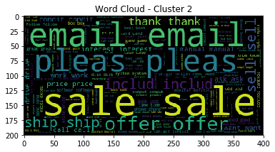

[figure not shown]

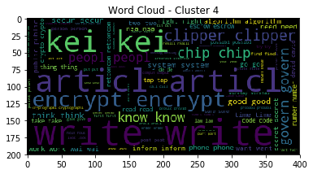

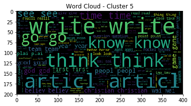

```python
from wordcloud import WordCloud

c1_wc = WordCloud(background_color = 'black').generate(c1_words)
plt.imshow(c1_wc)
plt.title('Word Cloud - Cluster 1')
plt.show()

c2_wc = WordCloud(background_color = 'black').generate(c2_words)
plt.imshow(c2_wc)
plt.title('Word Cloud - Cluster 2')
plt.show()

c3_wc = WordCloud(background_color = 'black').generate(c3_words)
plt.imshow(c3_wc)
plt.title('Word Cloud - Cluster 3')
plt.show()

c4_wc = WordCloud(background_color = 'black').generate(c4_words)
plt.imshow(c4_wc)
plt.title('Word Cloud - Cluster 4')
plt.show()

c5_wc = WordCloud(background_color = 'black').generate(c5_words)
plt.imshow(c5_wc)
plt.title('Word Cloud - Cluster 5')
plt.show()
```